# Text Clustering and Classification Example Notebook

*Author: Jacob Moore*

*Date: Jan 21, 2025*

This notebook is an example of how I would approach topic modeling unlabeled data, then use that topic model to produce a supervised classification model.

Below, I begin by loading the dataset. In this case, for simplicity, I am using **billingsmoore/text-clustering-example-data** which is a synthetic dataset that I have generated for clustering examples.

```python
from datasets import load_dataset

ds = load_dataset('billingsmoore/text-clustering-example-data', split='train')['text']

ds[0]
```

```
'The pickup truck was loaded with heavy construction materials.'
```

## Clustering

### Visualizing the Unclustered Data

Below I have produced a visualization of the data in 2 dimensions using the **easy_text_clustering** pipeline. This will help us get a sense of how our data are distributed. This pipeline embeds the texts using **MiniLM**, then projects those into 2 dimensions using **UMAP**. The visualization here is produced using **Pandas**.

The code used below sets 'embed_device' to cuda so that the embedding step will use GPU. If GPU is not available on your device you can remove this argument. I've also set 'summary_create' to False. This prevents the pipeline from generating cluster summaries. This is recommended to save time (and query tokens) during initial exploration.

In general, this step is not strictly necessary, but I perform it here for reference.

```
INFO:sentence_transformers.SentenceTransformer:Load pretrained SentenceTransformer: all-MiniLM-L6-v2
```

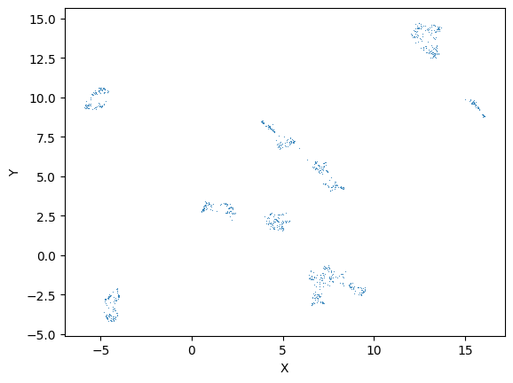

```python
from easy_text_clustering.clusterer import ClusterClassifier
import pandas as pd

cc = ClusterClassifier(embed_device='cuda', summary_create=False)
cc.embeddings = cc.embed(ds)
cc.projections, cc.mapper = cc.project(cc.embeddings, projection_algorithm='umap', projection_args={})

pd.DataFrame(data={"X": cc.projections[:, 0],
                    "Y": cc.projections[:, 1]}
            ).plot(kind="scatter",
                    x="X",
                    y="Y",
                    s=0.75,
                    alpha=0.8,
                    linewidth=0,
                    )
```

You can see in the visualization above that there are some clusters that are immediately apparent in the data. This will make finding reasonable clusters in this data relatively easy.

### Cluster the Data

Below, I have clustered the data using the **easy_text_clustering** pipeline. I've allowed the pipeline to use default hyperparameters for every step to get a baseline. This pipeline will, as above, embed the sentences using **MiniLM**, then projects those into 2 dimensions using **UMAP**. Those projected embeddings are then clustering using **HDBScan**.

Note, that I've defined a new ClusterClassifier instance. This is so that this code block can be recycled without alteration if you've skipped the previous step.

Be aware, also, that the error below is because 'summary_create' is set to False. This is a known bug in **easy_text_clustering** but does not prevent the visualization from being displayed correctly.

```
INFO:sentence_transformers.SentenceTransformer:Load pretrained SentenceTransformer: all-MiniLM-L6-v2
INFO:root:Embedding texts...
```

```
INFO:root:Building FAISS index...
INFO:root:Projecting with umap...
INFO:root:Clustering...
```

```
Using HDBSCAN params={}
```

[output not shown]

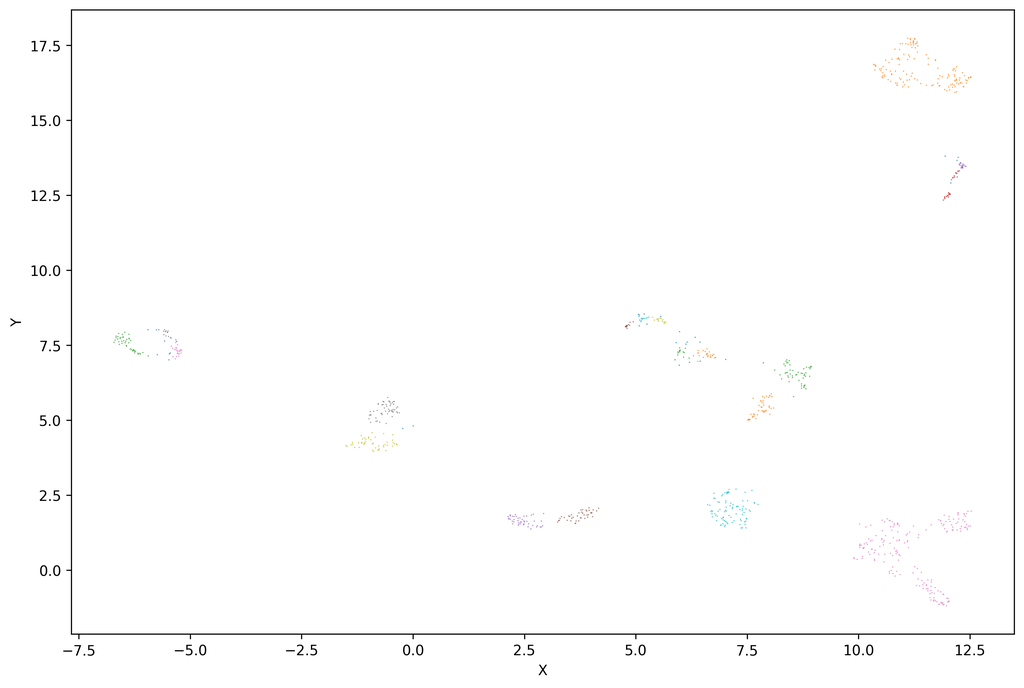

```python
from easy_text_clustering.clusterer import ClusterClassifier

cc = ClusterClassifier(embed_device='cuda', summary_create=False)
cc.fit(ds)
cc.show()
```

The clusters defined by the algorithm have been color-coded in the visualization above. You can see that some of the obvious clusters have been identified relatively well. However, there are some places where the algorithm has defined clusters that seem less than ideal. Below, I've evaluated the **silhouette score** for the clustering results.

The **silhouette score** is a metric used to evaluate the quality of clusters in unsupervised clustering. It measures how similar an object is to its own cluster compared to other clusters. The score ranges from **-1 to 1**, with the following interpretations:

- **1**: The object is well-matched to its own cluster and poorly matched to neighboring clusters (ideal clustering).
- **0**: The object lies on the boundary between clusters.
- **-1**: The object is closer to a neighboring cluster than to its own cluster (poor clustering).

The silhouette score for a single data point is calculated as:

$s = \frac{b - a}{\max(a, b)}$

Where:

- **a** is the average distance from the point to other points in the same cluster (intra-cluster distance).
- **b** is the average distance from the point to points in the nearest neighboring cluster (inter-cluster distance).

The **overall silhouette score** for the clustering is the mean silhouette score of all points.

```python
from sklearn.metrics import silhouette_score

score = silhouette_score(cc.projections, cc.cluster_labels)
print(float(score))
```

```
0.6312560439109802
```

A score of ~.63 is not terrible but we can do better. To improve the results, I can optimize for the best silhouette score using the optimizer from **easy_text_clustering**.

### Optimize Clustering

Below, I've intialized an Optimizer object to aim for a minimum and maximum number of clusters. For this example I've selected a range of 5-15 clusters. Looking at the visualizations above it seems like any greater or fewer than this would be less than ideal. I've also assigned score weights to only include silhouette score and number of clusters in its optimization.

I've then set the optimizer to run 15 trials to try to maximize the silhouette score with the given range of clusters. In general, a larger number of trials will tend to produce better results but this must be balanced against how long we want to run the optimization.

The optimizer will optimize the hyperparameters for **UMAP** projections ('projection_args') as well as for **HDBScan** clustering ('clustering args').

```python
from easy_text_clustering.optimizer import Optimizer

opt = Optimizer(min_clusters=5, max_clusters=15, score_weights=(1,0,0,1))

projection_args, clustering_args= opt.fit(cc.embeddings, optimization_trials=15)
```

```
[I 2025-01-21 17:09:24,686] A new study created in memory with name: no-name-b3873f65-67a1-4f59-9860-e2eb15db22d9
[I 2025-01-21 17:09:25,498] Trial 0 finished with value: 1.6009514927864075 and parameters: {'umap_n_neighbors': 10, 'umap_min_dist': 0.7434253972682717, 'hdbscan_min_cluster_size': 20, 'cluster_selection_epsilon': 0.8483120318372601}. Best is trial 0 with value: 1.6009514927864075.
[I 2025-01-21 17:09:26,161] Trial 1 finished with value: -0.31777602434158325 and parameters: {'umap_n_neighbors': 18, 'umap_min_dist': 0.752202936977659, 'hdbscan_min_cluster_size': 61, 'cluster_selection_epsilon': 0.0510109557612376}. Best is trial 0 with value: 1.6009514927864075.
[I 2025-01-21 17:09:26,896] Trial 2 finished with value: -2.344003677368164 and parameters: {'umap_n_neighbors': 31, 'umap_min_dist': 0.7571297364156484, 'hdbscan_min_cluster_size': 9, 'cluster_selection_epsilon': 0.045753371827973566}. Best is trial 0 with value: 1.6009514927864075.
[I 2025-01-21 17:09:27,511] Trial 3 finished with value: 1.7977063655853271 and parameters: {'umap_n_neighbors': 7, 'umap_min_dist': 0.35700064748288296, 'hdbscan_min_cluster_size': 32, 'cluster_selection_epsilon': 0.9139593492925862}. Best is trial 3 with value: 1.7977063655853271.
[I 2025-01-21 17:09:28,228] Trial 4 finished with value: -1.4417970180511475 and parameters: {'umap_n_neighbors': 45, 'umap_min_dist': 0.8762859683585964, 'hdbscan_min_cluster_size': 73, 'cluster_selection_epsilon': 0.7361824350811429}. Best is trial 3 with value: 1.7977063655853271.
[I 2025-01-21 17:09:28,875] Trial 5 finished with value: -1.0 and parameters: {'umap_n_neighbors': 9, 'umap_min_dist': 0.958185782834408, 'hdbscan_min_cluster_size': 95, 'cluster_selection_epsilon': 0.4457377114912747}. Best is trial 3 with value: 1.7977063655853271.
```

```
Number of labels is 1. Valid values are 2 to n_samples - 1 (inclusive)
```

```
[I 2025-01-21 17:09:29,488] Trial 6 finished with value: -1.3556371927261353 and parameters: {'umap_n_neighbors': 12, 'umap_min_dist': 0.8418241435125622, 'hdbscan_min_cluster_size': 66, 'cluster_selection_epsilon': 0.6405457325086021}. Best is trial 3 with value: 1.7977063655853271.
[I 2025-01-21 17:09:30,192] Trial 7 finished with value: 1.8696104288101196 and parameters: {'umap_n_neighbors': 22, 'umap_min_dist': 0.14173001339802704, 'hdbscan_min_cluster_size': 46, 'cluster_selection_epsilon': 0.03655743827707669}. Best is trial 7 with value: 1.8696104288101196.
[I 2025-01-21 17:09:30,950] Trial 8 finished with value: 1.8948246240615845 and parameters: {'umap_n_neighbors': 15, 'umap_min_dist': 0.10101548977162211, 'hdbscan_min_cluster_size': 16, 'cluster_selection_epsilon': 0.7471081590834295}. Best is trial 8 with value: 1.8948246240615845.
[I 2025-01-21 17:09:31,657] Trial 9 finished with value: 1.884504795074463 and parameters: {'umap_n_neighbors': 50, 'umap_min_dist': 0.10198497117968108, 'hdbscan_min_cluster_size': 8, 'cluster_selection_epsilon': 0.4394620920905822}. Best is trial 8 with value: 1.8948246240615845.
[I 2025-01-21 17:09:32,356] Trial 10 finished with value: 1.7926560640335083 and parameters: {'umap_n_neighbors': 35, 'umap_min_dist': 0.36556960283582823, 'hdbscan_min_cluster_size': 39, 'cluster_selection_epsilon': 0.2859785467228527}. Best is trial 8 with value: 1.8948246240615845.
[I 2025-01-21 17:09:33,241] Trial 11 finished with value: 1.8946095705032349 and parameters: {'umap_n_neighbors': 50, 'umap_min_dist': 0.02776474871215931, 'hdbscan_min_cluster_size': 7, 'cluster_selection_epsilon': 0.4982858333629191}. Best is trial 8 with value: 1.8948246240615845.
[I 2025-01-21 17:09:33,922] Trial 12 finished with value: 1.89981210231781 and parameters: {'umap_n_neighbors': 39, 'umap_min_dist': 0.0018649469158434906, 'hdbscan_min_cluster_size': 25, 'cluster_selection_epsilon': 0.6174785810533833}. Best is trial 12 with value: 1.89981210231781.
[I 2025-01-21 17:09:34,619] Trial 13 finished with value: 1.8366897702217102 and parameters: {'umap_n_neighbors': 38, 'umap_min_dist': 0.2299263150768207, 'hdbscan_min_cluster_size': 27, 'cluster_selection_epsilon': 0.6980544957573404}. Best is trial 12 with value: 1.89981210231781.
[I 2025-01-21 17:09:35,329] Trial 14 finished with value: 1.7850803136825562 and parameters: {'umap_n_neighbors': 25, 'umap_min_dist': 0.4808017478448179, 'hdbscan_min_cluster_size': 21, 'cluster_selection_epsilon': 0.9684473359280977}. Best is trial 12 with value: 1.89981210231781.
```

I can now refit the ClusterClassifier using the optimized hyperparameters.

```
INFO:root:Using precomputed embeddings...
INFO:root:Building FAISS index...
INFO:root:Using precomputed projections...
INFO:root:Clustering...
```

```
Using HDBSCAN params={'cluster_selection_method': 'leaf', 'min_cluster_size': 25, 'metric': 'euclidean', 'cluster_selection_epsilon': 0.6174785810533833}
```

[output not shown]

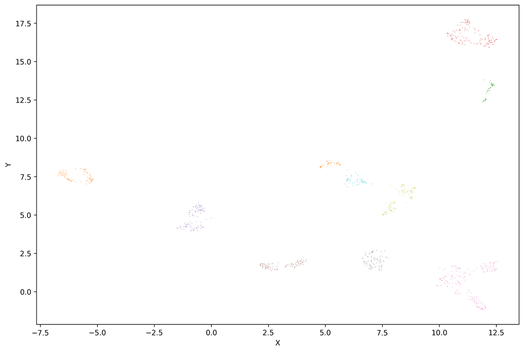

```python
cc.fit(projection_args=projection_args, clustering_args=clustering_args)
cc.show()
```

We can see from the color-coded visualization above that the clusters appear to better capture the obvious groups in the dataset. But, we can confirm this using silhouette score.

```python
score = silhouette_score(cc.projections, cc.cluster_labels)
print(float(score))
```

```
0.7237791419029236
```

The score of ~.72 above is an improvement! From here, we can either accept this improved result or, if we want to improve things further, we could re-run the optimizer to search for a better set of hyperparameters. For this example, I'll accept the improved score and move forward.

### Cluster Summarization

If cluster summaries are desired at this stage they can be added using the following code block.

This will send a random set of 10 samples to **Myxtral** to be summarized.

```
Request:
<s>[INST]Example 1:
The football game was intense, with both teams trading scores in the final minutes.

Example 2:
The football coach emphasized discipline and execution in practice.

Example 3:
The basketball player’s behind-the-back pass amazed everyone in the arena.

Example 4:
The running back leaped over the defensive line for a touchdown.

Example 5:
The quarterback’s composure under pressure was key to the team’s victory.

Example 6:
The football team’s defense held strong during a critical fourth-down stop.

Example 7:
Football games often feature strategic play-calling to exploit weaknesses.

Example 8:
The basketball player’s slam dunk brought the fans to their feet.

Example 9:
The kicker made a game-winning field goal as time expired.

Example 10:
The basketball team executed a perfect pick-and-roll play for an easy basket.

Use three words total (comma separated)to describe general topics in above texts. Under no circumstances use enumeration. Example format: Tree, Cat, Fireman[/INST]
Number of clusters is 11
```

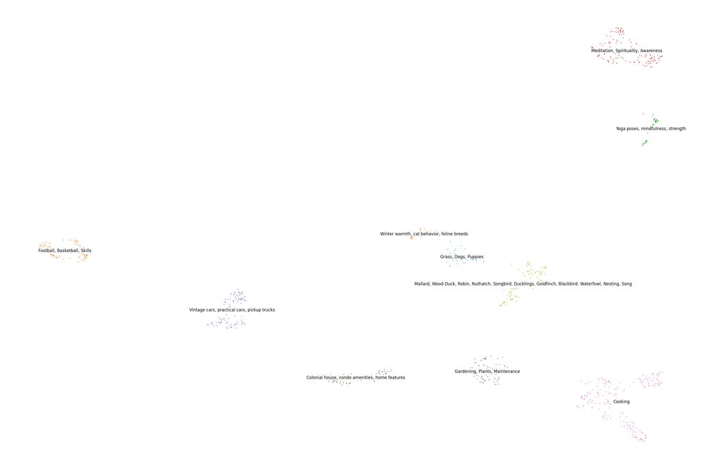

```python
cc.cluster_summaries = cc.summarize(texts=cc.texts, labels=cc.cluster_labels)
cc.show()
```

### Save Results

The ClusterClassifier, now complete with saved embeddings, projections, cluster labels, and summaries, can be saved and reloaded respectively with the two code blocks below.

ClusterClassifiers can be saved at any time so that computationally expensive work are not lost in between working sessions.

```python
cc.save('example-cc')
```

```python
from easy_text_clustering.clusterer import ClusterClassifier

cc = ClusterClassifier()
cc.load('example-cc')
```

```
INFO:sentence_transformers.SentenceTransformer:Load pretrained SentenceTransformer: all-MiniLM-L6-v2
```

## Classification Model

### Preparing Labeled Data

Now, that I have clustered the data, I can use the cluster labels as 'true' labels on the data. I can filter outliers from the data (cluster label -1), and then assign the remaining embeddings and labels to X and y variables for supervised classification.

Here I am training the classifier on the embeddings created by MiniLM. This could also be done by creating **tf-idf**, or any other, encodings. This can be an important decision for classifiers that are intended for use in real time applications because producing embeddings can become computationally expensive.

Note that I have set the 'test_size' for my dataset to 0.8. This is extremely large. More typical values are .2 or .15. However, the classifier consistently performed at nearly 100% accuracy and I wanted to leave room for improvement for the next step in this example.

```python
import xgboost as xgb
from sklearn.model_selection import train_test_split
from sklearn.metrics import accuracy_score

labeled_pairs = [[i, j] for i, j in zip(cc.embeddings, cc.cluster_labels) if int(j) != -1]

X = [elt[0] for elt in labeled_pairs]
y = [elt[1] for elt in labeled_pairs]

# Split data into training and testing sets
X_train, X_test, y_train, y_test = train_test_split(X, y, test_size=0.8, random_state=0)
```

### Training A Baseline Classifier

Below, I train a small XGBoost model to predict the cluster labels.

XGBoost (Extreme Gradient Boosting) is a supervised algorithm based on ensembled decision trees. It uses gradient boosting to optimize the model iteratively during training and implements regularization throughout that process to avoid overfitting.

Despite this, it trains very quickly, allowing us to train multiple version in a short time span to test different hyperparameters.

```python
# Train an XGBoost model
xgb_model = xgb.XGBClassifier(eval_metric='logloss')
xgb_model.fit(X_train, y_train)

# Make predictions
y_pred = xgb_model.predict(X_test)

# Evaluate the model
accuracy = accuracy_score(y_test, y_pred)
accuracy
```

```
0.851150202976996
```

This classifier has an accuracy of .85, which is not too bad, but there is clearly room for improvement.

Notably, this classifier also trained in just a minute and a half. This is a small dataset, but that is still much, much faster than training a transformer model for this task. The model itself is also much smaller and therefore much faster in producing predictions.

Like in the clustering steps above, we can improve performance using hyperparameter optimization.

### Optimize Classification

Below, I've implemented Bayesian optimization using the **hyperopt** library. Bayesian optimization probabilistically selects new hyperparameters to try based on the outcome of previous training and evaluation loops. This approach is also used by the **easy_text_clustering** optimizer but the code for this is abstracted in order to be user-friendly.

For this example, I've set the maximum number of trials to 15, but like before this could be set higher if you are willing to wait longer for results.

```python
from hyperopt import fmin, tpe, hp, STATUS_OK, STATUS_FAIL

# Define the search space
space = {
    'max_depth': hp.quniform('max_depth', 2, 8, 1),
    'learning_rate': hp.loguniform('learning_rate', -5, -2),
    'subsample': hp.uniform('subsample', 0.5, 1)
}

def objective(params):
    # Convert max_depth to an integer
    params['max_depth'] = int(params['max_depth'])
    try:
        # Train and evaluate the model
        opt_xgb_model = xgb.XGBClassifier(eval_metric='logloss', **params)
        opt_xgb_model.fit(X_train, y_train)
        y_pred = opt_xgb_model.predict(X_test)
        score = accuracy_score(y_test, y_pred)
        return {'loss': -score, 'status': STATUS_OK}
    except Exception as e:
        # Handle any errors gracefully
        return {'loss': float('inf'), 'status': STATUS_FAIL, 'exception': str(e)}

best_params = fmin(objective, space, algo=tpe.suggest, max_evals=15)

print('Best set of hyperparameters: ', best_params)
```

```
INFO:hyperopt.tpe:build_posterior_wrapper took 0.000607 seconds
INFO:hyperopt.tpe:TPE using 0 trials
```

```
INFO:hyperopt.tpe:build_posterior_wrapper took 0.001055 seconds
INFO:hyperopt.tpe:TPE using 1/1 trials with best loss -0.878214
```

```
INFO:hyperopt.tpe:build_posterior_wrapper took 0.000843 seconds
INFO:hyperopt.tpe:TPE using 2/2 trials with best loss -0.879567
```

```
INFO:hyperopt.tpe:build_posterior_wrapper took 0.000641 seconds
INFO:hyperopt.tpe:TPE using 3/3 trials with best loss -0.897158
```

```
INFO:hyperopt.tpe:build_posterior_wrapper took 0.000664 seconds
INFO:hyperopt.tpe:TPE using 4/4 trials with best loss -0.897158
```

```
INFO:hyperopt.tpe:build_posterior_wrapper took 0.001041 seconds
INFO:hyperopt.tpe:TPE using 5/5 trials with best loss -0.897158
```

```
INFO:hyperopt.tpe:build_posterior_wrapper took 0.000979 seconds
INFO:hyperopt.tpe:TPE using 6/6 trials with best loss -0.897158
```

```
INFO:hyperopt.tpe:build_posterior_wrapper took 0.000499 seconds
INFO:hyperopt.tpe:TPE using 7/7 trials with best loss -0.897158
```

```
INFO:hyperopt.tpe:build_posterior_wrapper took 0.000504 seconds
INFO:hyperopt.tpe:TPE using 8/8 trials with best loss -0.897158
```

```
INFO:hyperopt.tpe:build_posterior_wrapper took 0.000474 seconds
INFO:hyperopt.tpe:TPE using 9/9 trials with best loss -0.899865
```

```
INFO:hyperopt.tpe:build_posterior_wrapper took 0.000555 seconds
INFO:hyperopt.tpe:TPE using 10/10 trials with best loss -0.912043
```

```
INFO:hyperopt.tpe:build_posterior_wrapper took 0.000878 seconds
INFO:hyperopt.tpe:TPE using 11/11 trials with best loss -0.912043
```

```
INFO:hyperopt.tpe:build_posterior_wrapper took 0.000751 seconds
INFO:hyperopt.tpe:TPE using 12/12 trials with best loss -0.912043
```

```
INFO:hyperopt.tpe:build_posterior_wrapper took 0.000562 seconds
INFO:hyperopt.tpe:TPE using 13/13 trials with best loss -0.912043
```

```
INFO:hyperopt.tpe:build_posterior_wrapper took 0.000850 seconds
INFO:hyperopt.tpe:TPE using 14/14 trials with best loss -0.912043
```

```
Best set of hyperparameters:  {'learning_rate': np.float64(0.056862006966074956), 'max_depth': np.float64(6.0), 'subsample': np.float64(0.6669321056678875)}
Best set of hyperparameters:  {'learning_rate': np.float64(0.056862006966074956), 'max_depth': np.float64(6.0), 'subsample': np.float64(0.6669321056678875)}
```

Now, we can train a new model using the optimized hyperparameters.

```python
import numpy as np


best_params = {'learning_rate': np.float64(0.056862006966074956), 'max_depth': 6, 'subsample': np.float64(0.6669321056678875)}

opt_xgb_model = xgb.XGBClassifier(eval_metric='logloss', **best_params)
opt_xgb_model.fit(X_train, y_train)

# Make predictions
y_pred = opt_xgb_model.predict(X_test)

# Evaluate the model
accuracy = accuracy_score(y_test, y_pred)
accuracy
```

```
0.912043301759134
```

The model now achieves an accuracy score of .91, much improved from the previous result!

This model could now be saved and used later to classify new data as it comes in.

## A Brief Conclusion

Each step in this process can, of course, be made more complicated and different evaluation metrics may be more appropriate for different use cases.

However, the approach demonstrated here provides a useful baseline and reference point for tasks of this sort. My hope in producing this example is to introduce a helpful starting point and useful reference for future work.